# Day 4

## Review

When we have **one** *quantitative* variable we have several options:

#### **Histograms**

**Histogram**: visual representation of a frequency distribution

- **Not a bar graph**

Start by making a frequency distribution:

- Define classes (numeric intervals)
- Record the **frequency** of occurrences

| Class | 0.00-0.99 | 1.00-1.99 | 2.00-2.99 | 3.00-3.99 | 4.00-4.99 | 5.00-5.99 | 6.00-6.99 |
| --- | --- | --- | --- | --- | --- | --- | --- |
| Frequency | 9 | 18 | 16 | 14 | 4 | 3 | 1 |

**Lower class limit**: the smallest value that can appear in that class

**Upper class limit**: largest value that can appear in that class

**Class width**: the **difference** between consecutive lower class limits

General requirements for **quantitative frequency distributions**:

- Every observation must fall into one of the classes
- The classes must not overlap
- The classes must be of equal width
- There must be no gaps between classes

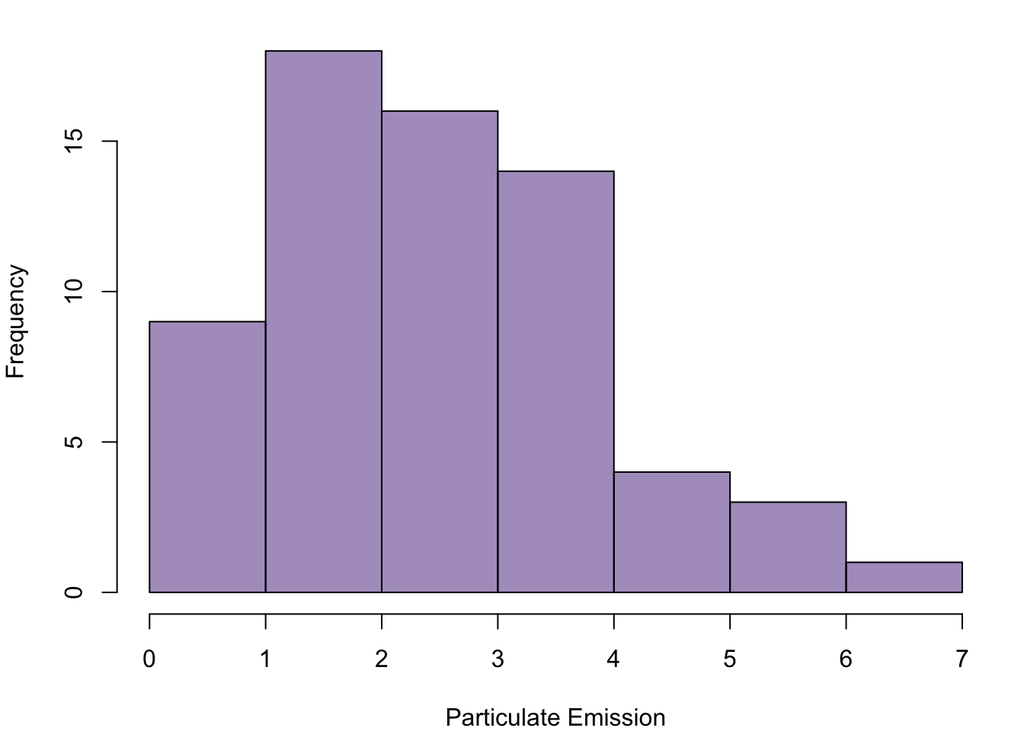

- Bar height (y-axis) represents class frequency
- Bar width (x-axis) represents class width
- Left edge of each bar corresponds to the lower class limit
- **No gaps between classes** so no gaps between bars of a histogram
- We care about the **shape** of our data
- The shape of our data can help us observe the **distribution** of our data
- Vocabulary for *describing* the shape of data:
  - **Symmetric** - mirror image on both sides of it’s center
  - **Positively-skewed** - Long, narrow tail to the **right**
  - **Negatively-skewed** - Long, narrow tail to the **left**
  - **Unimodal** - One peak/hump
  - **Bimodal** - two peaks/humps
  - **Uniform** - box
- Histograms can be used to summarize both small and large data sets
- Sometimes we prefer more detailed visualizations for smaller data sets

#### **Steam-and-leaf plots**

- Each observation should have *at least* **two** digits
  - The digit furthest to the **right** is the “leaf”
  - The digits to the **left** form the “stem”

$$\begin{array}{|c|c|c|c|c|c|c|c|c|c|}
\hline
87 & 7 & 95 & 76 & 32 & 28 & 84 & 98 & 93 & 88\\
\hline
78 & 100 & 68 & 76 & 55 & 65 & 42 & 57 & 77 & 96 \\
\hline
\end{array}$$

$$\begin{array}{r|l}
0 & 7 \\
1 & \\
2 & 8 \\
3 & 2 \\
4 & 2 \\
5 & 5 \; 7 \\
6 & 5 \; 8 \\
7 & 6 \; 6 \; 7 \; 8 \\
8 & 4 \; 7 \; 8 \\
9 & 3 \; 5 \; 6 \; 8 \\
10 & 0
\end{array}$$

#### **Dotplots**

- We can represent each observation by a dot above its value on a number line

$$\begin{array}{|c|c|c|c|c|}
\hline
3 & 6 & 2 & 5 & 1 \\
\hline
2 & 3 & 4 & 3 & 4 \\
\hline
\end{array}$$

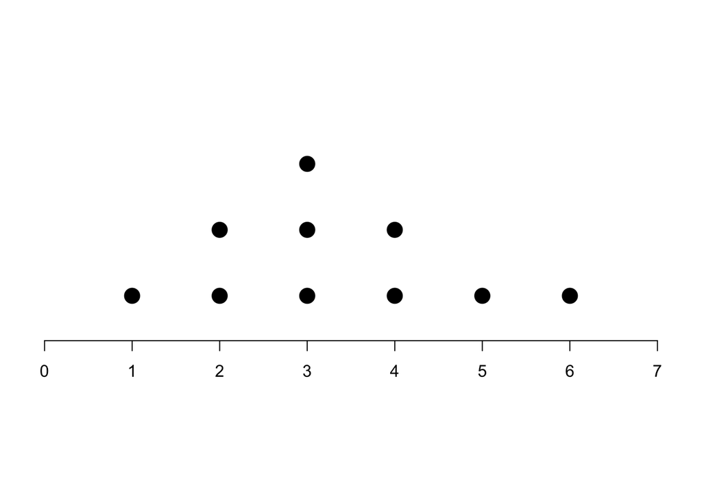

**Questions?**

**Goals for Today:**

1. Describe and calculate Mean, Median, and Mode
2. Recognize the use and importance of Statistical/Mathematical notation

## Graphical and Numerical Summaries

### Measures of Center

> Graphics are good for taking data and making it easier to view

> Numerical summaries are how we take data and make it easier to **understand**

*Refresher:*

- **Parameter** $\rightarrow$ population
- **Statistic** $\rightarrow$ sample

*Statistical Inference in a nutshell*

> “Using **sample** statistics to describe **population** parameters”

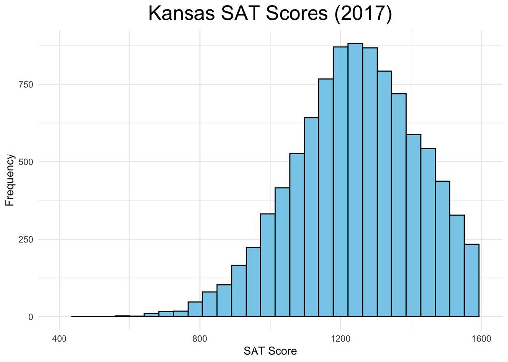

Which way is this histogram **skewed**?

How would you describe the **“center”** of this data?

- **Mean or average**: Balance point (fulcrum) of the dataset
- **Median**: Half of the data points are above the median, half are below
- **Mode**: Where the peak is

### Mean

**Sum all of the data then divide by the number of observations**

- Most commonly used metric for summarizing data

$$\begin{array}{|c|c|c|c|c|}
\hline
7 & 3 & 12 & 3 & 5 \\
\hline
\end{array}$$

$$\text{Mean} \ = \ {7+3+12+3+5 \over 5} = {30 \over 5} = 6$$

If the data we calculated a mean for comes from a **sample**:

- **Sample mean**

If the data we calculated a mean for comes from a **population**:

- **Population mean**

Which one is a **parameter**?

- A **statistic**?

Mathematical Notation Soapbox

- “Letter math”
- I resisted it forever
- But trust me, it does end up being helpful

Data values can be denoted as $x_1,x_2,x_3,...$

- $x_1$ refers to the observed value of the **variable** $x$ from **individual** 1
- $x$ can be anything
  - *It doesn’t even have to be* $x$
  - It’s convention, not law

**Sample size** (the number of individuals in the sample)

- Denoted with $n$ (Note: lower-case)

**Population size**

- Denoted with $N$ (Note: capital)

**Summation**

- This is referring to the sum (addition) of everything contained in the expression
- We denote this with the Greek letter $\Sigma$

With this notation we can describe:

$$\sum\limits_{i=1}^nx_i=x_1+x_2+...+x_n$$

- “The summation of $x_i$ to the $n^{th}$ term, starting from 1”

With sigma notation we can express the sample and population mean formulas:

- Sample mean (denoted $\bar{x}$):

$${1 \over n}\sum\limits_{i=1}^nx_i$$

- Population mean (denoted $\mu$):

$${1 \over N}\sum\limits_{i=1}^Nx_i$$

Greek letters usually mean **population parameters**

- Lower-case letters usually mean **sample statistics**
- In practice:

$$\begin{array}{|c|c|c|c|c|}
\hline
\text{Student} & 1 & 2 & 3 & 4 & 5 & 6 & 7 & 8 & 9 & 10 \\
\hline
\text{Abscences} & 2 & 6 & 1 & 2 & 4 & 0 & 1 & 3 & 0 & 2 \\
\hline
\end{array}$$

$${1 \over n}\sum\limits_{i=1}^nx_i$$

$${1 \over 10}(x_1+x_2+x_3+x_4+x_5+x_6+x_7+x_8+x_9+x_{10})$$

$${1 \over 10}(2+6+1+2+4+0+1+3+0+2)$$

$${1 \over 10} *21 = {21 \over 10} = 2.1$$

*Properties of the mean:*

- Common
- Easy to interpret
- Susceptible to **outliers**
  - The average number of Super Bowl rings between me and Tom Brady is $3.5$
  - (As of 2021) the top $1\%$ of households in the United States hold $32.3\%$ of the country’s wealth, while the bottom $50\%$ hold $2.6\%$
  - A statistic is **resistant** if its value is not affected heavily by **outliers**

*Is the mean resistant?*

### Median

**Middle value, half the data are below and half are above**

$$\begin{array}{|c|c|c|c|c|}
\hline
7 & 3 & 12 & 3 & 5 \\
\hline
\end{array}$$

Sort your data in **increasing** order (low to high)

$$\begin{array}{|c|c|c|c|c|}
\hline
3 & 3 & \boldsymbol{5} & 7 & 12 \\
\hline
\end{array}$$

The median is **5**

If $n$ is **odd**: choose position ${(n+1)\over2}$ in the ordered dataset

- So $n=5$

$${(n+1)\over2}={(5+1)\over2}=3$$

We pick the $3^{rd}$ data point after sorting

$$\begin{array}{|c|c|c|c|c|c|}
\hline
7 & 3 & 12 & 3 & 5 & 8\\
\hline
\end{array}$$

If $n$ is **even** *after ordering*:

- Pick $n\over 2$ and ${n \over 2}+1$
- Average the two data points

$$\begin{array}{|c|c|c|c|c|}
\hline
3 & 3 & \boldsymbol{5} & \boldsymbol{7} & 8 & 12 \\
\hline
\end{array}$$

$$n=6$$

$${6\over 2}=3 \ ,\ {6 \over 2}+1=4$$

- 3rd data point: $5$
- 4th data point: $7$

$${(5+7)\over 2}=6$$

The median is $6$

*Properties of median:*

- It doesn’t use all of the data directly
- This makes it **resistant**
  - Outliers have little/no effect
- Sometimes a more realistic measurement:
  - Median Household Income (Kansas): $\$57,422$
  - Average Household Income (Kansas): $\$77,509$
    - Why does median make more sense than average here?
- Difference between median and mean depend on *skew* of the histogram

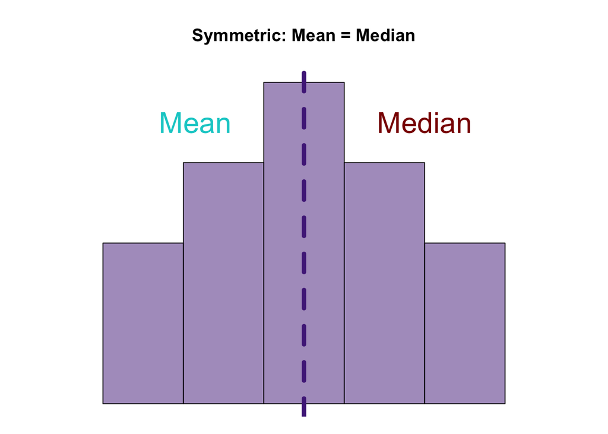

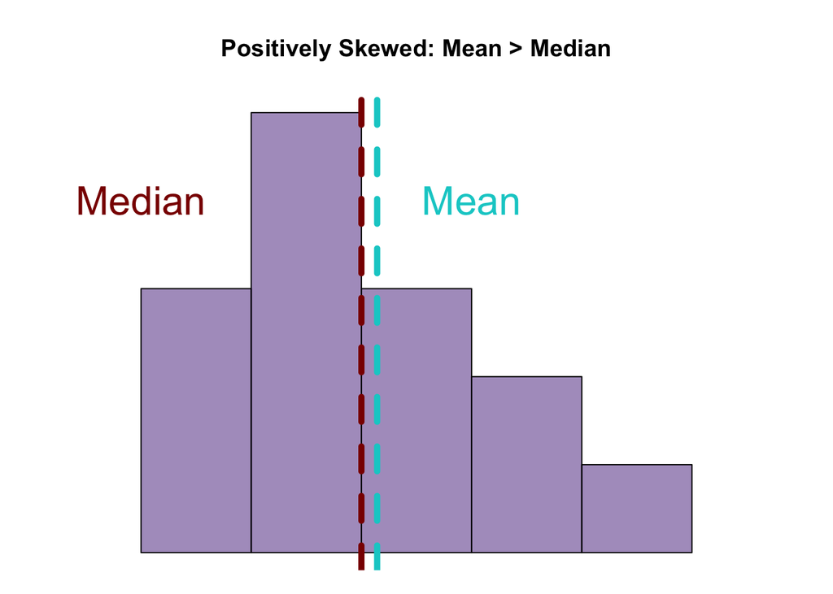

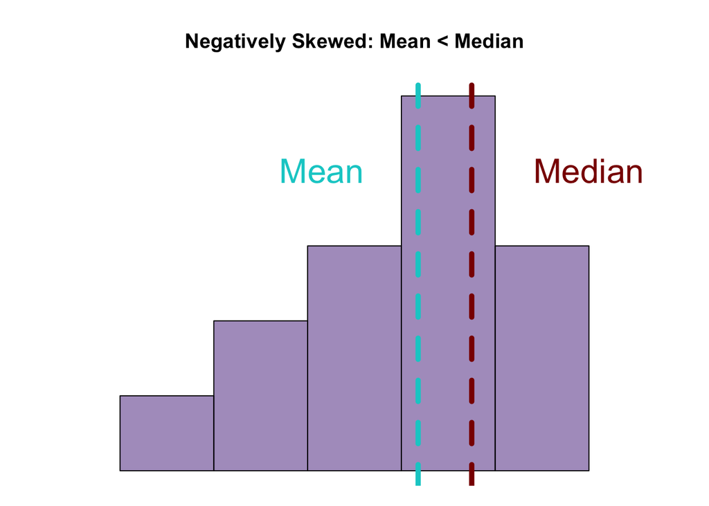

### Mode

**The most frequent observation**

Useful for qualitative data

- “Which credit card is most commonly used by our customers?”

Not as useful for quantitative data

- “What’s the most common weight of cattle on our research farms?”
  - Why isn’t this a helpful metric?

A data set can have any number of modes $(0,1,2,...)$

$$\begin{array}{|c|c|c|c|c|}
\hline
3 & 3 & 5 & 7 & 12 \\
\hline
\end{array}$$

The most frequently observed value in this data set is $3$

- The mode is $3$

The below data set displays a sample of $n=7$ observations:

$$\begin{array}{|c|c|c|c|c|c|c|}
\hline
2 & 1 & 3 & 4 & 3 & 5 & 4 \\
\hline
\end{array}$$

1. Find the **mean**, round to two decimal places if necessary:
2. Find the **median**, round to two decimal places if necessary:
3. Find the **mode(s)**:

A group of restaurants reported in a recent year that the mean price for their dinner was $\$18$, and the median was $\$22$.

If a histogram was constructed for the price of dinner at the group of restaurants, would you expect it to be skewed to the **right**, skewed to the **left**, or approximately **symmetric**?